# Opportunity for Income Predictor, county-level

Author

JP Walsh

Published

January 31, 2024

*Program for the creation of the Opportunity for Income Predictor at the county level*

ACS Code: Initially written by Tina Chelidze and updated by JP Walsh 2022-2023.

Primary data derived from the IPUMS API.

Based on processes developed by Paul Johnson and Kevin Werner in SAS.

- Housekeeping
- Read Data
- Clean Data
- Merge Crosswalk
- Create Income Metric
- Evaluate Results
- Export

## Housekeeping

Read in packages for use. If you do not have an IPUMS API key you will need to make one via the [IPUMS website](https://www.ipums.org/).

```r
library(tidyverse)
library(Hmisc)
library(ipumsr)
library(reactable)
library(srvyr)
library(scales)

options(scipen = 999)

# DO NOT PUSH YOUR API KEY. You only have to run this once and then comment it out as below.
#set_ipums_api_key("INSERT KEY HERE", save = TRUE, overwrite = TRUE)

source(here::here("functions", "API", "extract_ipums.R"))
```

## Read Data

Read in the ACS extracts using the extract_ipums function. Make sure to change the survey list to reflect what years you want to include in the data. Currently we are including three years of 1-year data (2018a, 2021a and 2022a) and two years of 5-year data (2018c and 2021c). 5-year 2022 data will be added pending its release.

```r
acs <- extract_ipums(
  extract_name = "umf_data_18_22",
  extract_description = "Microdata pull for Mobility Metric Predictors. American Community Survey, years 2018, 2019 and 2022 (1 and 5-year).",
  survey = list("us2018a", "us2021a", "us2022a", "us2018c", "us2021c")
)
```

Look at the distribution of samples in the data. The 5-year data sets should comprise a larger share of the total sample.

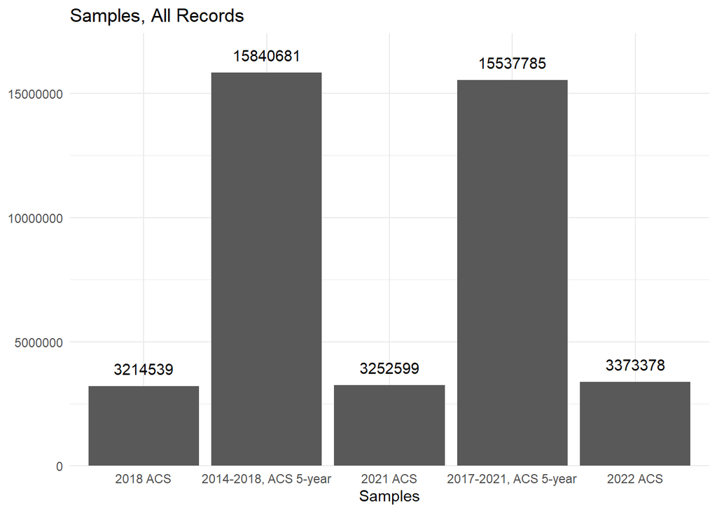

```r
acs %>%
  count(sample) %>%
  ggplot(mapping = aes(x = sample, y = n)) +
  geom_col() +
  theme_minimal() +
  ggtitle("Samples, All Records") +
 geom_text(mapping = aes(label = n), vjust = -1) +
  scale_y_continuous(expand = expansion(mult = c(0, 0.1))) +
  labs(x = "Samples",
       y = NULL)
```

Read in the PUMA to county crosswalk file. This file is created by the program generate_puma_county_crosswalks.rmd in the geographic-crosswalks folder.

```r
puma_county_crosswalk <- read_csv(here::here("geographic-crosswalks", "data", "crosswalk_puma_to_county.csv"))
```

Crate a version of the crosswalk with just the county-level values of data quality variables for each crosswalk period.

```r
county_puma <- puma_county_crosswalk %>%
  group_by(crosswalk_period, statefip, county) %>%
  summarise(geographic_allocation_quality = mean(geographic_allocation_quality)) %>%
  ungroup()
```

## Clean Data

Missing data is reported in a variety of ways by IPUMS - listed below:

HHINCOME is missing it is reported as “9999999”. Vacancy is reported as “0”.

There is a large share of records missing HHINCOME. However, note there are no vacancy results by default of the structure of census data read in.

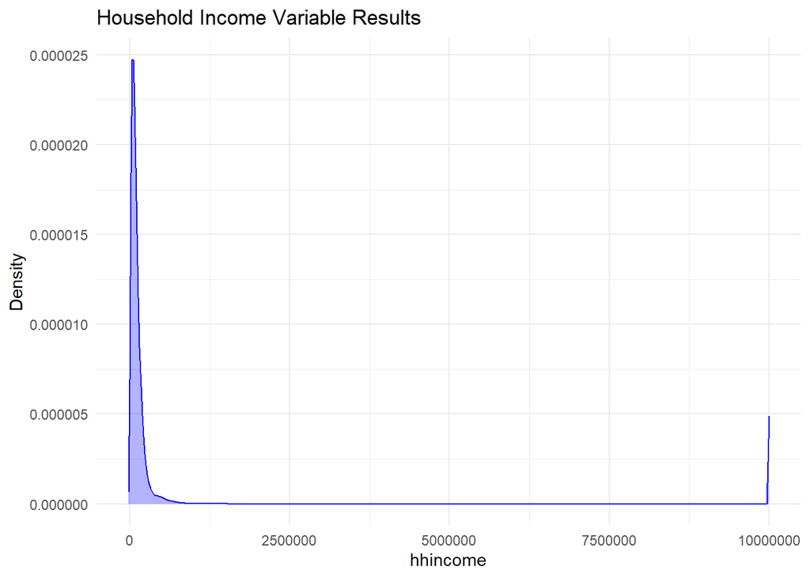

```r
acs %>%
  ggplot(aes(x = hhincome)) +
  geom_density(color = "blue", fill = alpha("blue", 0.3)) +
  theme_minimal() +
  ggtitle("Household Income Variable Results") +
  ylab("Density")
```

[figure not shown]

```r
acs %>%
  ggplot(aes(x = vacancy)) +
  geom_density(color = "blue", fill = alpha("blue", 0.3)) +
  theme_minimal() +
  ggtitle("Vacancy Variable Results") +
  ylab("Density")
```

Turn the missing/“not in universe” values for the hhincome variable into NAs. Remove original data to save space.

```r
acs_clean <- acs %>%
  mutate(hhincome = ifelse(hhincome == 9999999, NA_integer_,
                           hhincome)
         )

rm(acs)
```

Look at distribution of HHINCOME after adjustment. Some outliers will still exist but bunching around the missing value should not be present.

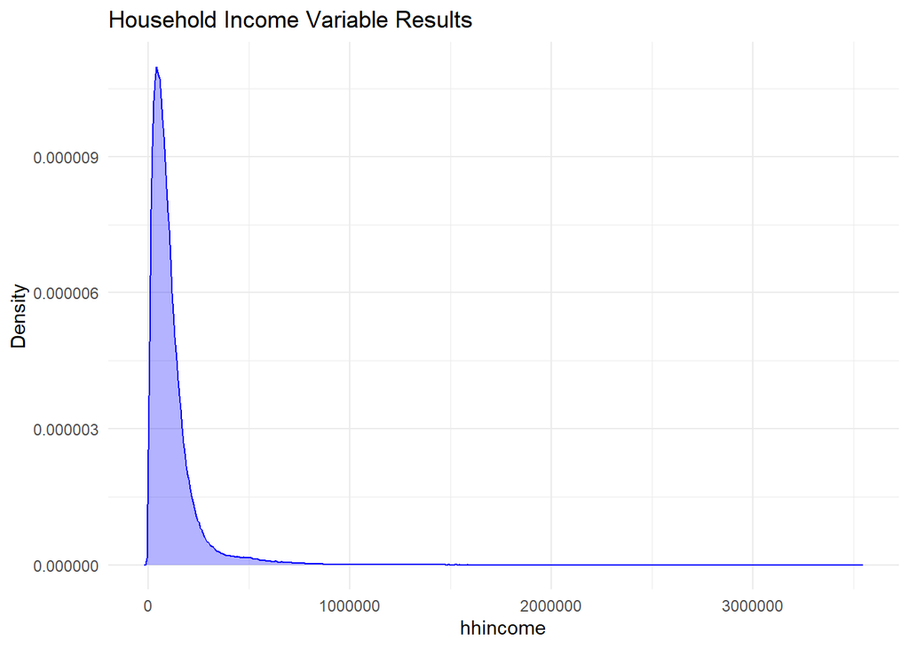

```r
acs_clean %>%
  ggplot(aes(x = hhincome)) +
  geom_density(color = "blue", fill = alpha("blue", 0.3)) +
  theme_minimal() +
  ggtitle("Household Income Variable Results") +
  ylab("Density")
```

Select our group quarters, we want to keep only households including additional households under updated definitions.

```r
acs_clean %>%
  group_by(gq) %>%
  count()
```

```
# A tibble: 5 x 2
# Groups:   gq [5]
  gq                                                 n
  <fct>                                          <int>
1 Households under 1970 definition            39093662
2 Additional households under 1990 definition    73638
3 Group quarters--Institutions                  977950
4 Other group quarters                         1063725
5 Additional households under 2000 definition    10007
```

```r
acs_clean <- acs_clean %>%
  filter(gq %in% c("Households under 1970 definition",
                   "Additional households under 1990 definition",
                   "Additional households under 2000 definition"))
```

Check that group quarters fall only into household categories.

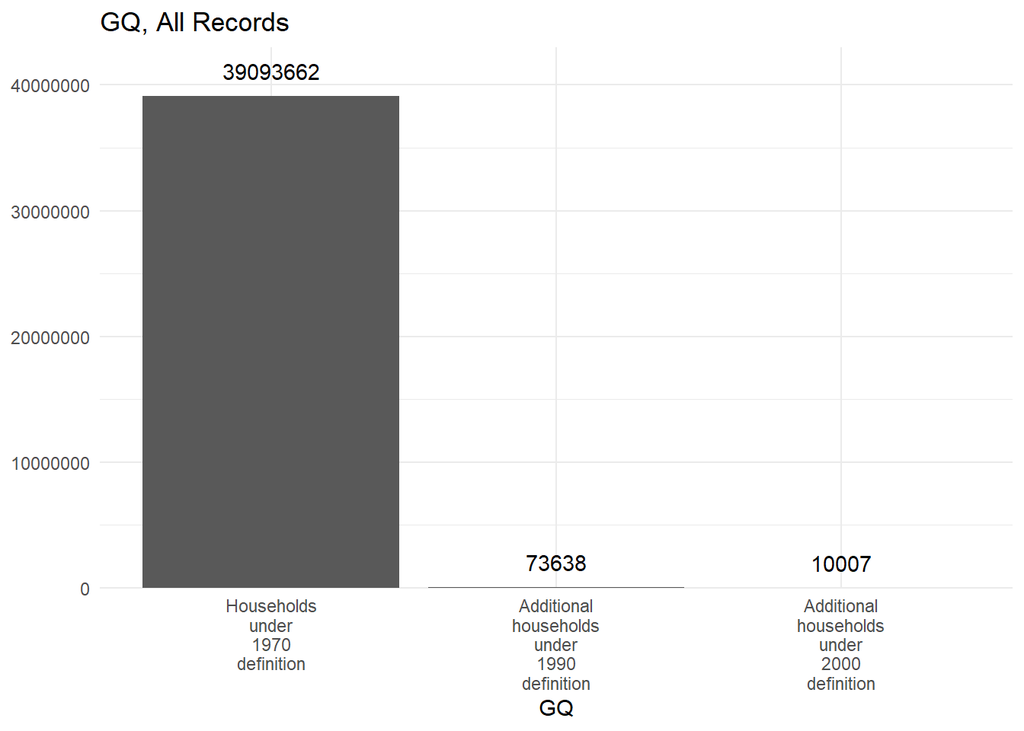

```r
acs_clean %>%
  count(gq) %>%
  ggplot(mapping = aes(x = gq, y = n)) +
  geom_col() +
  theme_minimal() +
  ggtitle("GQ, All Records") +
 geom_text(mapping = aes(label = n), vjust = -1) +
  scale_y_continuous(expand = expansion(mult = c(0, 0.1))) +
  labs(x = "GQ",
       y = NULL)+
  scale_x_discrete(labels = label_wrap(10))
```

### Create race variable

Evaluate the values in the RACE and HISPAN variables.

- IPUMS documented values for RACE:
  - 1 White
  - 2 Black/African American/Negro
  - 3 American Indian or Alaska Native
  - 4 Chinese
  - 5 Japanese
  - 6 Other Asian or Pacific Islander
  - 7 Other race
  - 8 Two major races
  - 9 Three or more major races
- IPUMS documented values for HISPAN:
  - 0 Not Hispanic
  - 1 Mexican
  - 2 Puerto Rican
  - 3 Cuban
  - 4 Other
  - 9 Not Reported

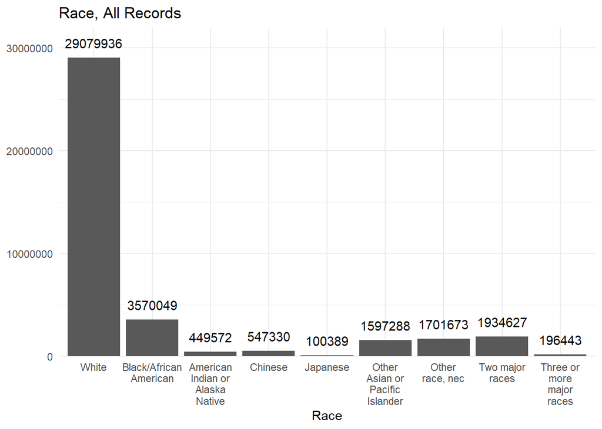

```r
acs_clean %>%
  count(race) %>%
  ggplot(mapping = aes(x = race, y = n)) +
  geom_col() +
  theme_minimal() +
  ggtitle("Race, All Records") +
 geom_text(mapping = aes(label = n), vjust = -1) +
  scale_y_continuous(expand = expansion(mult = c(0, 0.1))) +
  labs(x = "Race",
       y = NULL)+
  scale_x_discrete(labels = label_wrap(10))
```

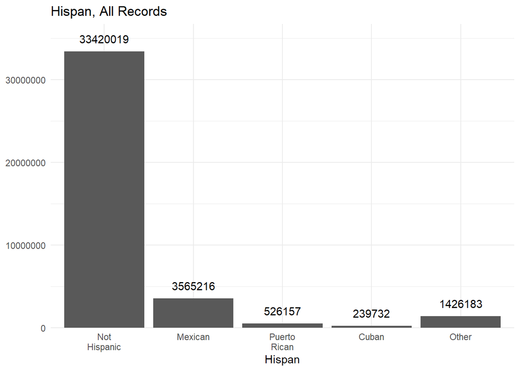

```r
acs_clean %>%
  count(hispan) %>%
  ggplot(mapping = aes(x = hispan, y = n)) +
  geom_col() +
  theme_minimal() +
  ggtitle("Hispan, All Records") +
 geom_text(mapping = aes(label = n), vjust = -1) +
  scale_y_continuous(expand = expansion(mult = c(0, 0.1))) +
  labs(x = "Hispan",
       y = NULL)+
  scale_x_discrete(labels = label_wrap(10))
```

Create the race/ethnicity variable. For other race/ethnicity categories not coded as Hispanic, Hispan must be equal to “Not Hispanic”.

```r
acs_clean <- acs_clean %>%
  mutate(subgroup = case_when((hispan == "Not Hispanic" & race == "White") ~ "White, Non-Hispanic",
                              (hispan == "Not Hispanic" & race == "Black/African American") ~ "Black, Non-Hispanic",
                              (hispan == "Not Hispanic" & !race %in% c("Black/African American", "White")) ~ "Other Races and Ethnicities",
                               hispan != "Not Hispanic" ~ "Hispanic"
  ))
```

Look at subgroup distribution.

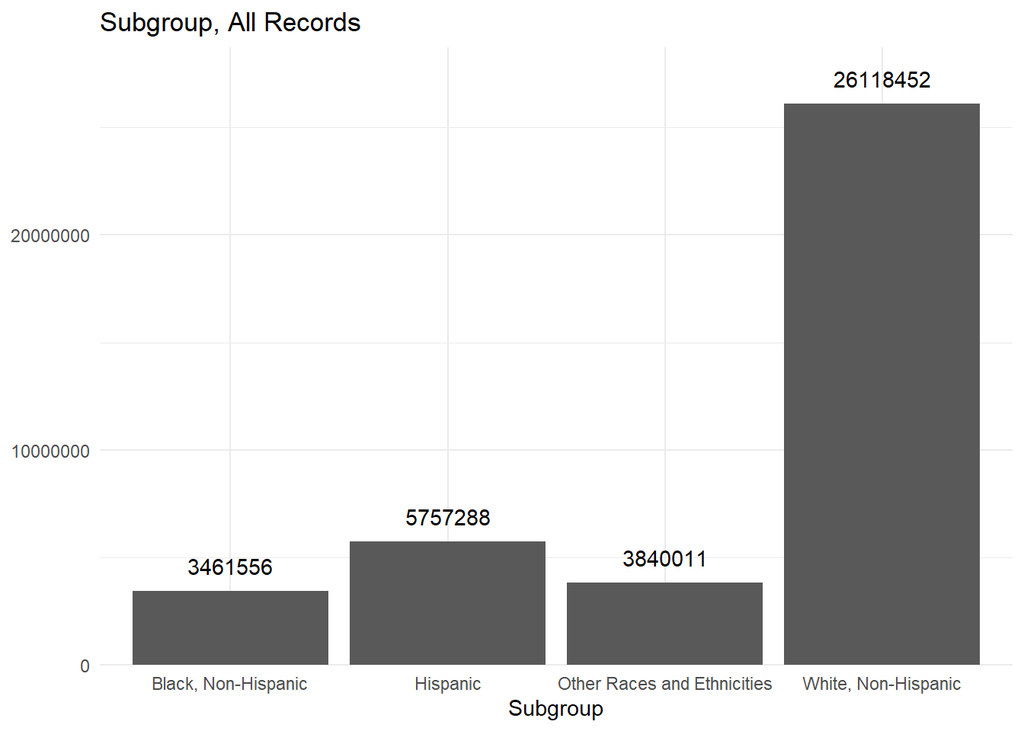

```r
acs_clean %>%
  count(subgroup) %>%
  ggplot(mapping = aes(x = factor(subgroup), y = n)) +
  geom_col() +
  theme_minimal() +
  ggtitle("Subgroup, All Records") +
 geom_text(mapping = aes(label = n), vjust = -1) +
  scale_y_continuous(expand = expansion(mult = c(0, 0.1))) +
  labs(x = "Subgroup",
       y = NULL)
```

## Merge Crosswalk

Create a variable in the ACS data indicating whether the survey is pre or post-2022. This will be used to join on the correct crosswalk information.

```r
acs_clean <- acs_clean %>%
  mutate(crosswalk_period = ifelse(year < 2022, "pre-2022", "2022"))
```

Check that the assignment worked. All years prior to 2022 should be designated “pre-2022”.

```r
acs_clean %>%
  group_by(crosswalk_period, year) %>%
  count()
```

```
# A tibble: 3 x 3
# Groups:   crosswalk_period, year [3]
  crosswalk_period  year        n
  <chr>            <int>    <int>
1 2022              2022  3192208
2 pre-2022          2018 18155811
3 pre-2022          2021 17829288
```

Join the cleaned ACS data onto the crosswalk. This is a many-to-many join because we are aggregating from PUMA to county.

```r
acs_clean <- left_join(acs_clean, puma_county_crosswalk,
                       by=c("crosswalk_period", "statefip","puma"),
                       relationship = "many-to-many")
```

Drop any observations with NA for afact (i.e. there is no county of interest overlapping this PUMA).

```r
acs_clean <- acs_clean %>%
    drop_na(afact)
```

Also filter out cases where AFACT is equal to zero.

```r
acs_clean <- acs_clean %>%
  filter(afact > 0)
```

Adjust weight to account for PUMA-to-county mapping (those where unique_types do not equal 1).Drop PUMA flag variable from PUMA_county.

Apply the Adjust variable to household income. Adjust converts the dollar amounts to the amount that they would have been had they been earned entirely during the calendar year. This is to deal with households being surveyed at different times during the year.

```r
acs_clean <- acs_clean %>%
  mutate(hhwt = hhwt*afact,
         hhincome = hhincome*adjust
  )
```

Isolate data to include each household only once (PERNUM == 1 counts head of household only).

```r
acs_clean <- acs_clean %>%
  filter(pernum == 1)
```

Create a binary variable to distinguish between 1 and 5 year ACS datasets. 5-year samples include the term “5-year”.

```r
acs_clean <- acs_clean %>%
  mutate(sample_structure = ifelse(str_detect(sample, "5-year"), "5year", "1year"))
```

Confirm there are no missing values remaining in the data set for the household income variable.

```r
acs_clean %>%
  filter(is.na(hhincome)) %>%
  count()
```

```
# A tibble: 1 x 1
      n
  <int>
1     0
```

Confirm there are no vacant properties included in the data.

```r
acs_clean %>%
  filter(is.na(vacancy)) %>%
  count()
```

```
# A tibble: 1 x 1
      n
  <int>
1     0
```

## Create Income Metric

Create the income metric for each county overall and for race subgroups.

Objective: Calculate the 20th, 50th and 80th percentile of household income for all unique state+county combinations in all years.

Aggregation should be weighted by HHWT (this is a household level statistic).

### All

Calculate income quantiles by county.

```r
metrics_income_all <- acs_clean %>%
  filter(sample_structure == "1year") %>%
  group_by(year, crosswalk_period, statefip, county) %>%
  summarise(
    pctl_income_20 = Hmisc::wtd.quantile(hhincome, weights = hhwt, probs = 0.2, type = "i/n"),
    pctl_income_50 = Hmisc::wtd.quantile(hhincome, weights = hhwt, probs = 0.5, type = "i/n"),
    pctl_income_80 = Hmisc::wtd.quantile(hhincome, weights = hhwt, probs = 0.8, type = "i/n")
  ) %>%
  ungroup()
```

Sort by year, state and county.

```r
metrics_income_all <- metrics_income_all %>%
  arrange(year, statefip, county)
```

*Create an indicator for data quality and suppression*

Calculate the effective sample count for each county.

```r
effective_sample <- acs_clean %>%
  filter(sample_structure == "1year") %>%
  group_by(year, crosswalk_period, statefip, county) %>%
  summarise(effective_sample = sum(afact)) %>%
  ungroup()
```

Merge the data quality flag on geographic allocation from the crosswalk on to the metric data.

```r
metrics_income_all <- left_join(metrics_income_all, county_puma, by=c("crosswalk_period", "statefip","county"))

metrics_income_all <- left_join(metrics_income_all, effective_sample, by=c("year", "crosswalk_period", "statefip","county"))
```

```r
# Generate base data
reactable_data <- metrics_income_all %>%
  mutate(
    effective_sample_cutoffs = case_when(
      effective_sample < 30 ~ "Less than 30",
      effective_sample >= 30 &
        effective_sample <= 100 ~ "Over 30 but 100 or less",
      effective_sample > 100 &
        effective_sample <= 300 ~ "Over 100 but 300 or less",
      TRUE ~ "Greater than 300"
    ),
    effective_sample_cutoffs = factor(
      effective_sample_cutoffs,
      levels = c(
        "Less than 30",
        "Over 30 but 100 or less",
        "Over 100 but 300 or less",
        "Greater than 300"
      )
    )
  )

# Get suppression factor for each year of data
suppression_factor <- reactable_data %>%
  group_by(year) %>%
  summarize(yearly_total = n()) %>%
  select(year, yearly_total)

# Create reactable for further examination
reactable_data %>%
  left_join(suppression_factor, by="year") %>%
  group_by(year,effective_sample_cutoffs) %>%
  summarize(n = n(), suppression_share = n()/unique(yearly_total)) %>% # yearly value has one unique value per year
  reactable()
```

| year | effective_sample_cutoffs | n | suppression_share |
| --- | --- | --- | --- |
| 2018 | Less than 30 | 355 | 0.112949411390391 |
| 2018 | Over 30 but 100 or less | 982 | 0.312440343620745 |
| 2018 | Over 100 but 300 or less | 981 | 0.312122176264715 |
| 2018 | Greater than 300 | 825 | 0.262488068724149 |
| 2021 | Less than 30 | 361 | 0.114858415526567 |
| 2021 | Over 30 but 100 or less | 968 | 0.307986000636335 |
| 2021 | Over 100 but 300 or less | 977 | 0.310849506840598 |
| 2021 | Greater than 300 | 837 | 0.2663060769965 |
| 2022 | Less than 30 | 349 | 0.111040407254216 |
| 2022 | Over 30 but 100 or less | 926 | 0.294622971683105 |

[output cut: 2 more lines]

Generate the quality variable. Mark cases where the effective sample is less than 100, these will be assigned a data quality of 3.

```r
metrics_income_all <- metrics_income_all %>%
  mutate(effective_sample_flag = ifelse(effective_sample < 100, 1, 0),

         pctl_20_quality = case_when(effective_sample_flag==0 & geographic_allocation_quality==1 ~ 1,
                                     effective_sample_flag==0 & geographic_allocation_quality==2 ~ 2,
                                     effective_sample_flag==0 & geographic_allocation_quality==3 ~ 3,
                                     effective_sample_flag==1 ~ 3),

         pctl_50_quality = case_when(effective_sample_flag==0 & geographic_allocation_quality==1 ~ 1,
                                     effective_sample_flag==0 & geographic_allocation_quality==2 ~ 2,
                                     effective_sample_flag==0 & geographic_allocation_quality==3 ~ 3,
                                     effective_sample_flag==1 ~ 3),

         pctl_80_quality = case_when(effective_sample_flag==0 & geographic_allocation_quality==1 ~ 1,
                                     effective_sample_flag==0 & geographic_allocation_quality==2 ~ 2,
                                     effective_sample_flag==0 & geographic_allocation_quality==3 ~ 3,
                                     effective_sample_flag==1 ~ 3)
  )
```

We do not want to show values that are calculated from less than 30 samples in the data. These points will be suppressed and shown as missing or NA. Suppress the results for values generated from less than 30 samples.

```r
metrics_income_all <- metrics_income_all %>%
  mutate_at(c("pctl_income_20", "pctl_income_50", "pctl_income_80"), ~if_else(effective_sample < 30, NA_integer_, .))
```

Keep only relevant variables.

```r
metrics_income_all <- metrics_income_all %>%
  select(year, statefip, county, pctl_income_20, pctl_20_quality,
         pctl_income_50, pctl_50_quality, pctl_income_80,
         pctl_80_quality)
```

### Subgroups

Calculate income quantiles by race/ethnicity and county (5-year data).

```r
metrics_income_subgroup <- acs_clean %>%
  filter(sample_structure == "5year") %>%
  group_by(year, crosswalk_period, statefip, county, subgroup) %>%
  summarise(
    pctl_income_20 = Hmisc::wtd.quantile(hhincome, weights = hhwt, probs = 0.2, type = "i/n"),
    pctl_income_50 = Hmisc::wtd.quantile(hhincome, weights = hhwt, probs = 0.5, type = "i/n"),
    pctl_income_80 = Hmisc::wtd.quantile(hhincome, weights = hhwt, probs = 0.8, type = "i/n")
  ) %>%
  ungroup() %>%
  mutate(subgroup_type = "race-ethnicity")
```

Calculate quantiles for all households with the 5-year data. To be appended onto the subgroup data by race/ethnicity.

```r
metrics_income_subgroup_all <- acs_clean %>%
  filter(sample_structure == "5year") %>%
  group_by(year, crosswalk_period, statefip, county) %>%
  summarise(
    pctl_income_20 = Hmisc::wtd.quantile(hhincome, weights = hhwt, probs = 0.2, type = "i/n"),
    pctl_income_50 = Hmisc::wtd.quantile(hhincome, weights = hhwt, probs = 0.5, type = "i/n"),
    pctl_income_80 = Hmisc::wtd.quantile(hhincome, weights = hhwt, probs = 0.8, type = "i/n")
  ) %>%
  ungroup() %>%
  mutate(subgroup_type = "all",
         subgroup = "All")
```

Append the “All” version of the data.

```r
metrics_income_sub <- bind_rows(metrics_income_subgroup, metrics_income_subgroup_all)
```

Sort by year, state and county.

```r
metrics_income_sub <- metrics_income_sub %>%
  arrange(year, statefip, county)
```

*Create an indicator for data quality and suppression*

Calculate the effective sample count for each county.

```r
effective_sample_sub_all <- acs_clean %>%
  filter(sample_structure == "5year") %>%
  group_by(year, crosswalk_period, statefip, county) %>%
  summarise(effective_sample = sum(afact)) %>%
  mutate(subgroup_type = "all",
         subgroup = "All")

effective_sample_sub <- acs_clean %>%
  filter(sample_structure == "5year") %>%
  group_by(year, crosswalk_period, statefip, county, subgroup) %>%
  summarise(effective_sample = sum(afact)) %>%
  mutate(subgroup_type = "race-ethnicity") %>%
  bind_rows(effective_sample_sub_all) %>%
  ungroup()
```

Merge the data quality flag on geographic allocation from the crosswalk on to the metric data.

```r
metrics_income_sub <- left_join(metrics_income_sub, county_puma, by=c("crosswalk_period", "statefip","county"))

metrics_income_sub <- left_join(metrics_income_sub, effective_sample_sub, by=c("year", "crosswalk_period", "statefip","county", "subgroup_type", "subgroup"))
```

Tabulate effective sample counts for each subgroup, defined as the sum of the afact for that group in each county. Look at the distribution of counties by potential cutoffs (30, 100, 300). This is to measure data quality for each county based on the number of records reported.

```r
income_reactable_data <- metrics_income_sub %>%
  mutate(
    effective_sample_cutoffs = case_when(
      effective_sample < 30 ~ "Less than 30",
      effective_sample >= 30 &
        effective_sample <= 100 ~ "Over 30 but 100 or less",
      effective_sample > 100 &
        effective_sample <= 300 ~ "Over 100 but 300 or less",
      TRUE ~ "Greater than 300"
    ),
    effective_sample_cutoffs = factor(
      effective_sample_cutoffs,
      levels = c(
        "Less than 30",
        "Over 30 but 100 or less",
        "Over 100 but 300 or less",
        "Greater than 300"
      )
    )
  )

# Create reactable for further examination using suppression factor defined earlier
income_reactable_data %>%
  left_join(suppression_factor, by="year") %>%
  group_by(year, subgroup, effective_sample_cutoffs) %>%
  summarize(n = n(), suppression_share = n()/unique(yearly_total)) %>% # yearly value has one unique value per year
  reactable()
```

| year | subgroup | effective_sample_cutoffs | n | suppression_share |
| --- | --- | --- | --- | --- |
| 2018 | All | Less than 30 | 42 | 0.0133630289532294 |
| 2018 | All | Over 30 but 100 or less | 181 | 0.0575882914412981 |
| 2018 | All | Over 100 but 300 or less | 626 | 0.199172764874324 |
| 2018 | All | Greater than 300 | 2294 | 0.729875914731149 |
| 2018 | Black, Non-Hispanic | Less than 30 | 1956 | 0.622335348393255 |
| 2018 | Black, Non-Hispanic | Over 30 but 100 or less | 485 | 0.154311167674197 |
| 2018 | Black, Non-Hispanic | Over 100 but 300 or less | 370 | 0.11772192173083 |
| 2018 | Black, Non-Hispanic | Greater than 300 | 332 | 0.105631562201718 |
| 2018 | Hispanic | Less than 30 | 2087 | 0.664015272033089 |
| 2018 | Hispanic | Over 30 but 100 or less | 533 | 0.169583200763602 |

[output cut: 30 more lines]

Generate the quality variable. Mark cases where the effective sample is less than 100, these will be assigned a data quality of 3.

```r
metrics_income_sub <- metrics_income_sub %>%
  mutate(
    effective_sample_flag = ifelse(effective_sample < 100, 1, 0),
    pctl_20_quality = case_when(
      effective_sample_flag == 0 & geographic_allocation_quality == 1 ~ 1,
      effective_sample_flag == 0 &
        geographic_allocation_quality == 2 ~ 2,
      effective_sample_flag == 0 &
        geographic_allocation_quality == 3 ~ 3,
      effective_sample_flag == 1 ~ 3
    ),
    pctl_50_quality = case_when(
      effective_sample_flag == 0 & geographic_allocation_quality == 1 ~ 1,
      effective_sample_flag == 0 &
        geographic_allocation_quality == 2 ~ 2,
      effective_sample_flag == 0 &
        geographic_allocation_quality == 3 ~ 3,
      effective_sample_flag == 1 ~ 3
    ),
    pctl_80_quality = case_when(
      effective_sample_flag == 0 & geographic_allocation_quality == 1 ~ 1,
      effective_sample_flag == 0 &
        geographic_allocation_quality == 2 ~ 2,
      effective_sample_flag == 0 &
        geographic_allocation_quality == 3 ~ 3,
      effective_sample_flag == 1 ~ 3
    )
  )
```

We do not want to show values that are calculated from less than 30 samples in the data. These points will be suppressed and shown as missing or NA. Suppress the results for values generated from less than 30 samples.

```r
metrics_income_sub <- metrics_income_sub %>%
  mutate_at(c("pctl_income_20", "pctl_income_50", "pctl_income_80"), ~if_else(effective_sample < 30, NA_integer_, .))
```

Keep only relevant variables.

```r
metrics_income_sub <- metrics_income_sub %>%
  select(year, statefip, county, subgroup_type, subgroup, pctl_income_20, pctl_20_quality,
         pctl_income_50, pctl_50_quality, pctl_income_80,
         pctl_80_quality)
```

## Evaluate Results

Summarize the predictors for the 1-year and 5-year data.

```r
metrics_income_all %>%
  select(pctl_income_20:pctl_80_quality) %>%
  summary()
```

```
 pctl_income_20  pctl_20_quality pctl_income_50   pctl_50_quality
 Min.   : 9069   Min.   :1.000   Min.   : 26126   Min.   :1.000
 1st Qu.:20153   1st Qu.:2.000   1st Qu.: 49045   1st Qu.:2.000
 Median :24241   Median :3.000   Median : 56820   Median :3.000
 Mean   :25136   Mean   :2.495   Mean   : 59006   Mean   :2.495
 3rd Qu.:28825   3rd Qu.:3.000   3rd Qu.: 65902   3rd Qu.:3.000
 Max.   :84647   Max.   :3.000   Max.   :178418   Max.   :3.000
 NA's   :1065                    NA's   :1065
 pctl_income_80   pctl_80_quality
 Min.   : 65928   Min.   :1.000
 1st Qu.: 96072   1st Qu.:2.000
 Median :108302   Median :3.000
 Mean   :113613   Mean   :2.495
 3rd Qu.:124467   3rd Qu.:3.000
 Max.   :381387   Max.   :3.000
 NA's   :1065
```

```r
metrics_income_sub %>%
  select(pctl_income_20:pctl_80_quality) %>%
  summary()
```

```
 pctl_income_20  pctl_20_quality pctl_income_50   pctl_50_quality
 Min.   :    0   Min.   :1.000   Min.   : 15658   Min.   :1.000
 1st Qu.:18512   1st Qu.:3.000   1st Qu.: 44470   1st Qu.:3.000
 Median :23033   Median :3.000   Median : 53058   Median :3.000
 Mean   :23627   Mean   :2.635   Mean   : 54818   Mean   :2.635
 3rd Qu.:27271   3rd Qu.:3.000   3rd Qu.: 62130   3rd Qu.:3.000
 Max.   :98052   Max.   :3.000   Max.   :205150   Max.   :3.000
 NA's   :12307                   NA's   :12307
 pctl_income_80   pctl_80_quality
 Min.   : 35333   Min.   :1.000
 1st Qu.: 87945   1st Qu.:3.000
 Median :101836   Median :3.000
 Mean   :105572   Mean   :2.635
 3rd Qu.:116710   3rd Qu.:3.000
 Max.   :367318   Max.   :3.000
 NA's   :12307
```

Look at distributions of income percentiles by county for all (2022 and 2021).

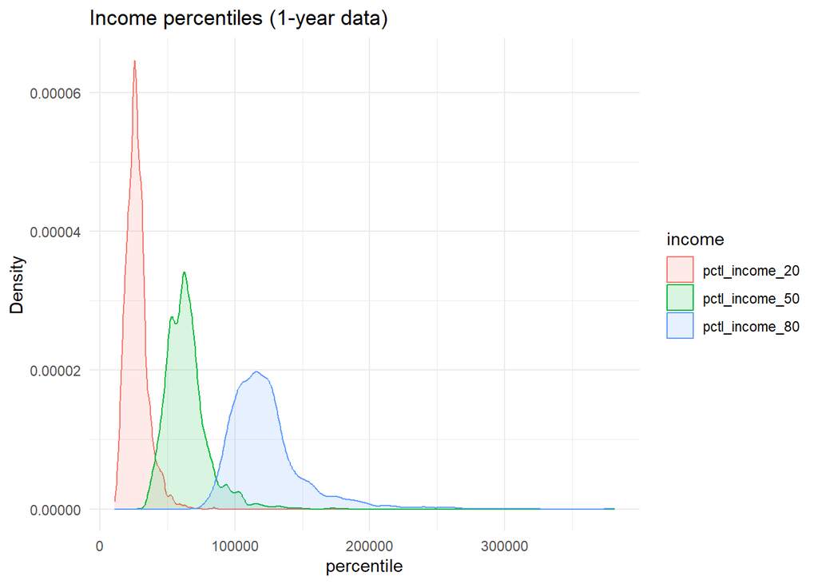

```r
metrics_income_all %>%
  filter(year == 2022) %>%
  select(pctl_income_20, pctl_income_50, pctl_income_80) %>%
  pivot_longer(cols = c(pctl_income_20, pctl_income_50, pctl_income_80), names_to = "income", values_to = "percentile") %>%
  ggplot(aes(x = percentile, color = income, fill = income)) +
  geom_density(alpha = 0.15) +
  theme_minimal() +
  ggtitle("Income percentiles (1-year data)") +
  ylab("Density")
```

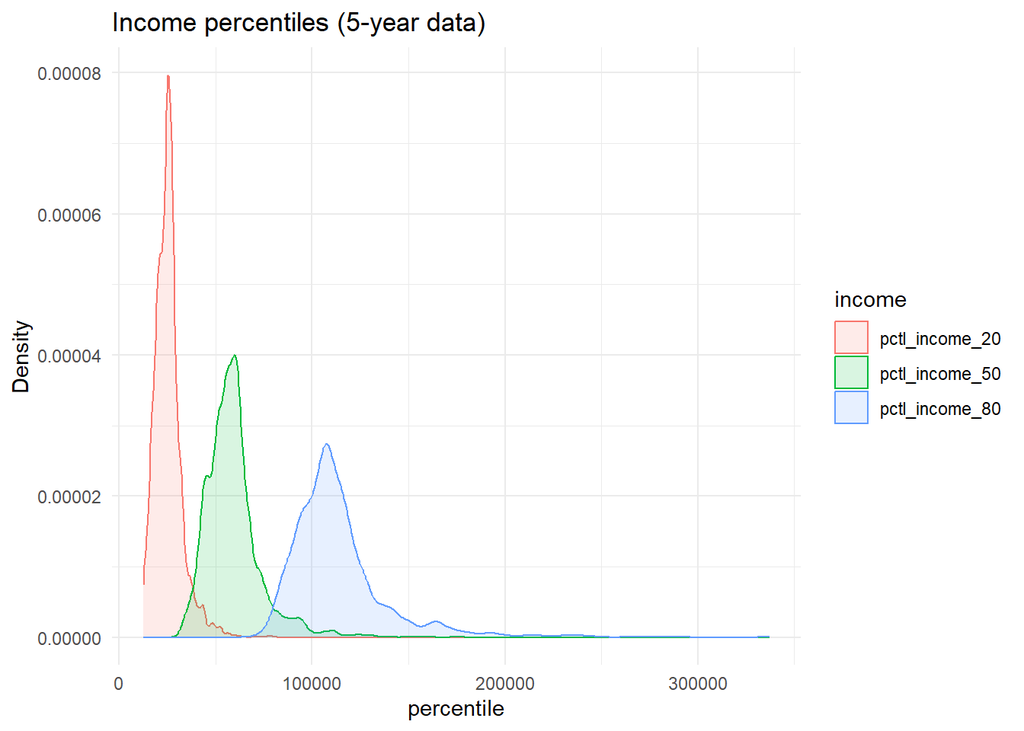

```r
metrics_income_sub %>%
  filter(year == 2021, subgroup == "All") %>%
  select(pctl_income_20, pctl_income_50, pctl_income_80) %>%
  pivot_longer(cols = c(pctl_income_20, pctl_income_50, pctl_income_80), names_to = "income", values_to = "percentile") %>%
  ggplot(aes(x = percentile, color = income, fill = income)) +
  geom_density(alpha = 0.15) +
  theme_minimal() +
  ggtitle("Income percentiles (5-year data)") +
  ylab("Density")
```

Break out distributions by subgroup (2021).

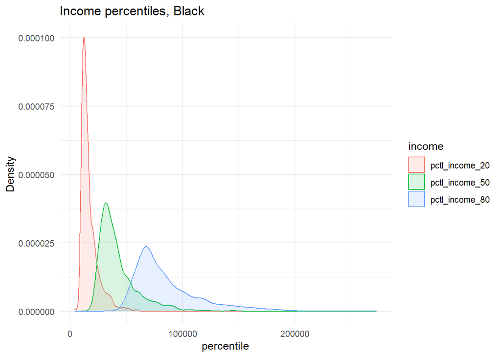

```r
metrics_income_sub %>%
  filter(year == 2021, subgroup == "Black, Non-Hispanic") %>%
  select(county, pctl_income_20, pctl_income_50, pctl_income_80) %>%
  pivot_longer(cols = c(pctl_income_20, pctl_income_50, pctl_income_80), names_to = "income", values_to = "percentile") %>%
  ggplot(aes(x = percentile, color = income, fill = income)) +
  geom_density(alpha = 0.15) +
  theme_minimal() +
  ggtitle("Income percentiles, Black") +
  ylab("Density")
```

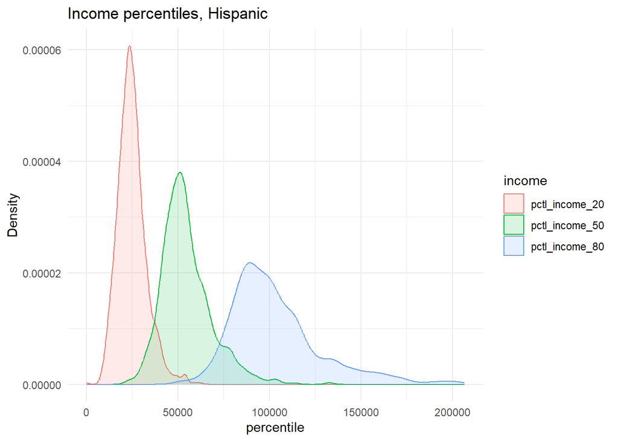

```r
metrics_income_sub %>%
  filter(year == 2021, subgroup == "Hispanic") %>%
  select(county, pctl_income_20, pctl_income_50, pctl_income_80) %>%
  pivot_longer(cols = c(pctl_income_20, pctl_income_50, pctl_income_80), names_to = "income", values_to = "percentile") %>%
  ggplot(aes(x = percentile, color = income, fill = income)) +
  geom_density(alpha = 0.15) +
  theme_minimal() +
  ggtitle("Income percentiles, Hispanic") +
  ylab("Density")
```

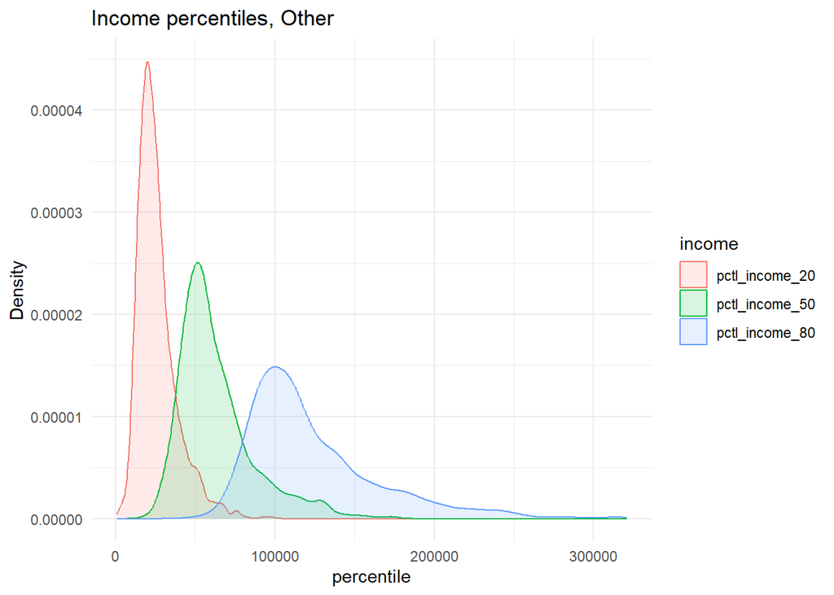

```r
metrics_income_sub %>%
  filter(year == 2021, subgroup == "Other Races and Ethnicities")  %>%
  select(county, pctl_income_20, pctl_income_50, pctl_income_80) %>%
  pivot_longer(cols = c(pctl_income_20, pctl_income_50, pctl_income_80), names_to = "income", values_to = "percentile") %>%
  ggplot(aes(x = percentile, color = income, fill = income)) +
  geom_density(alpha = 0.15) +
  theme_minimal() +
  ggtitle("Income percentiles, Other") +
  ylab("Density")
```

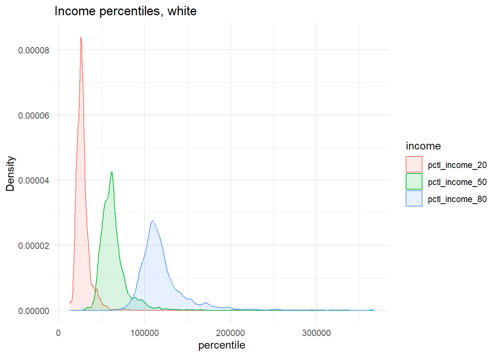

```r
metrics_income_sub %>%
  filter(year == 2021, subgroup == "White, Non-Hispanic")  %>%
  select(county, pctl_income_20, pctl_income_50, pctl_income_80) %>%
  pivot_longer(cols = c(pctl_income_20, pctl_income_50, pctl_income_80), names_to = "income", values_to = "percentile") %>%
  ggplot(aes(x = percentile, color = income, fill = income)) +
  geom_density(alpha = 0.15) +
  theme_minimal() +
  ggtitle("Income percentiles, white") +
  ylab("Density")
```

Look at the counts of the quality flag (all years).

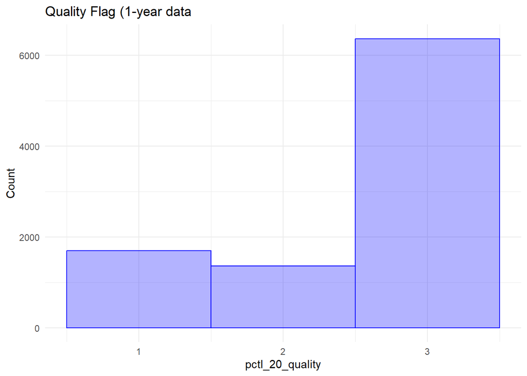

```r
metrics_income_all %>%
  select(pctl_20_quality) %>%
  ggplot(aes(x = pctl_20_quality)) +
  geom_histogram(color = "blue", fill = alpha("blue", 0.3), binwidth = 1.0) +
  theme_minimal() +
  ggtitle("Quality Flag (1-year data") +
  ylab("Count")
```

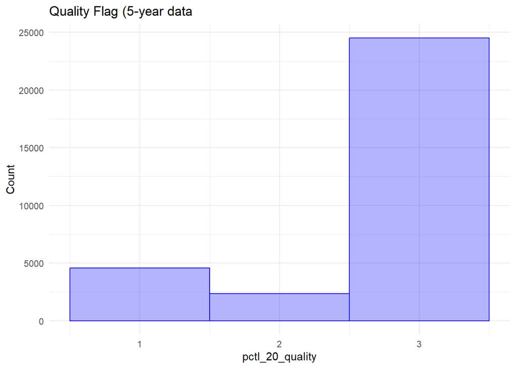

```r
metrics_income_sub %>%
  select(pctl_20_quality) %>%
  ggplot(aes(x = pctl_20_quality)) +
  geom_histogram(color = "blue", fill = alpha("blue", 0.3), binwidth = 1.0) +
  theme_minimal() +
  ggtitle("Quality Flag (5-year data") +
  ylab("Count")
```

Tabulate share of data suppressed by year.

```r
metrics_income_all %>%
  group_by(year) %>%
  filter(is.na(pctl_income_20)) %>%
  count()
```

```
# A tibble: 3 x 2
# Groups:   year [3]
   year     n
  <int> <int>
1  2018   355
2  2021   361
3  2022   349
```

```r
metrics_income_sub %>%
  group_by(year) %>%
  filter(is.na(pctl_income_20)) %>%
  count()
```

```
# A tibble: 2 x 2
# Groups:   year [2]
   year     n
  <int> <int>
1  2018  6302
2  2021  6005
```

## Export

Rename state.

```r
metrics_income_all <- metrics_income_all %>%
  rename("state" = "statefip")

metrics_income_sub <- metrics_income_sub %>%
  rename("state" = "statefip")
```

Order the variables how we want.

```r
metrics_income_all <- metrics_income_all %>%
  select(year, state, county, pctl_income_20, pctl_20_quality, pctl_income_50,
         pctl_50_quality, pctl_income_80, pctl_80_quality)

metrics_income_sub <- metrics_income_sub %>%
  select(year, state, county, subgroup_type, subgroup, pctl_income_20, pctl_20_quality, pctl_income_50,
         pctl_50_quality, pctl_income_80, pctl_80_quality)
```

Export as CSV

```r
write_csv(metrics_income_all, here::here("01_financial-well-being", "data", "final", "metrics_income_county_all_longitudinal.csv"))
write_csv(metrics_income_sub, here::here("01_financial-well-being", "data", "final", "metrics_income_county_race-ethnicity_longitudinal.csv"))
```